# Course Visualization Project

Sook Yee Leung

# Introduction

My data exploration and visualization centered around predicting pupils of Netherland’s characteristics vis-a-vis the nlschools dataset and, ultimately, analyzing how their characteristics affected their academic performance in language testing.

The following indicates an outline of my main steps and findings considering the guiding questions: **1. Are there descrepancies in `IQ` or `SES` in the different classes, or when grouping by multi-grade vs non-multi-grade classes?**

**2. When did students perform better or worse on the language exam? Describe which variables had the most important effects.**

- Main steps:
- Backwards and forwards variable selection with linear variables (df= 1)
  - Findings: Both method yielded the same model.
  - All variables except class size was kept.
  - Upon checking the residuals, it was found that the resdiuals were not identically distributed and that perhaps a more complex, nonlinear model may make better predictions.
  - The IQ variable in particular lacked a reasonable identically distributed fit.
- Used a generalized additive model with forward selection
  - Findings: A nonlinear fit was added for the SES variable (df =2) rather than for the IQ variable.
  - It was possible that including interaction terms in the model may better account for predicting lang (language scores).

**3. Do you think there are interactions in the effects of the variables on the language exam score? Speculate as to the cause of any such effects that you think should be included.**

- Main steps:
- Modelled interactions with the Generalized Additive Model using forward selection
  - Findings: The IQ:COMB term was added to the previous model, indicating that IQ and Class type interaction may aid in better prediction of the language scores.
- Co-plots to view interactions
  - Finding: There is an interaction between IQ and SES that contributes to predicting language scores.
  - In particular, those with a higher SES but lower IQ tend to outperform those with a low SES and a low IQ.
- Model-based clustering
  - Finding: Depicted and described three groups of pupils in the Netherlands, demonstrating the relationship between academic performance and IQ that is moderated by SES.
    - Group 1: High SES and moderate academic performance group (low IQ)
    - Group 2: High SES and high academic performance group (high IQ)
    - Group 3: Low SES group (diverse IQ)

# Analysis

These are the libraries used in the analysis.

```r
library(ggplot2)
library(plyr)
library(reshape2)
library(splines)
library(boot)
library(MASS)
library(broom)
library(Hmisc)
#Save the original graph as a dataframe object to manipulate clumns for plotting
nlschools.df = nlschools

#Summary statistics
summary(nlschools.df)
```

```
##       lang             IQ            class            GS
##  Min.   : 9.00   Min.   : 4.00   15580  :  33   Min.   :10.00
##  1st Qu.:35.00   1st Qu.:10.50   5480   :  31   1st Qu.:23.00
##  Median :42.00   Median :12.00   15980  :  31   Median :27.00
##  Mean   :40.93   Mean   :11.83   16180  :  31   Mean   :26.51
##  3rd Qu.:48.00   3rd Qu.:13.00   18380  :  31   3rd Qu.:31.00
##  Max.   :58.00   Max.   :18.00   5580   :  30   Max.   :39.00
##                                  (Other):2100
##       SES        COMB
##  Min.   :10.00   0:1658
##  1st Qu.:20.00   1: 629
##  Median :27.00
##  Mean   :27.81
##  3rd Qu.:35.00
##  Max.   :50.00
##
```

1. Are there descrepancies in `IQ` or `SES` in the different classes, or when grouping by multi-grade vs non-multi-grade classes?

Plots of different classes

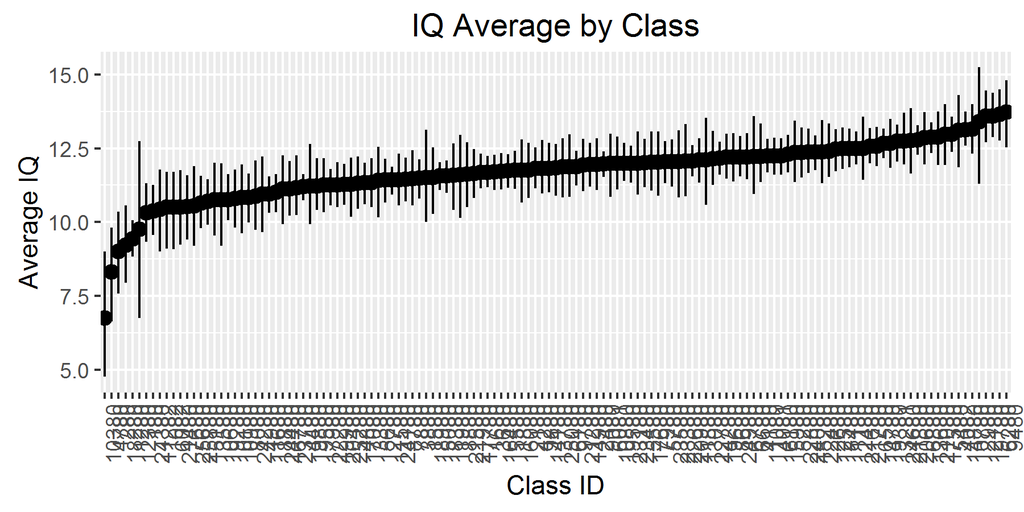

```r
##Re-order class id by IQ
nlschools.df$class = with(nlschools.df, reorder(class, IQ))

#Plot class by IQ to better view patterns across IQ averages per class and the confidence intervals
ggplot(data = nlschools.df, mapping=aes(x = class, y = IQ, group = class)) + stat_summary(fun.data = mean_cl_boot, geom='pointrange') + labs(title= 'IQ Average by Class', x = 'Class ID', y = 'Average IQ') + theme(axis.text.x = element_text(angle = 90, hjust = 1))
```

```r
#Rotate x labels source:
# http://stackoverflow.com/questions/1330989/rotating-and-spacing-axis-labels-in-ggplot2
```

It seems that each class has a relatively similar group of students in terms of IQ. In other words, all classes do not have wide confidence intervals that span accross the bottommost and uppermost IQ values. The confidence intervals tend to be fairly narrow and restricted to approximate variations of +/-2.5 according to 95% confidence level limits.

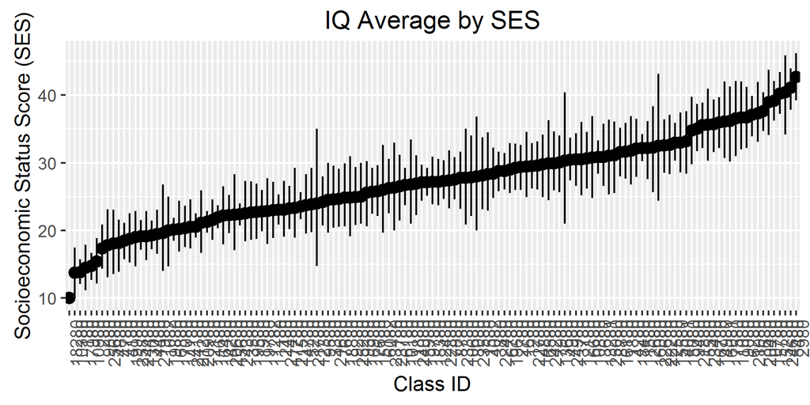

```r
##Re-order class id by SES to better view patterns across SES score averages per class and the confidence intervals
nlschools.df$class = with(nlschools.df, reorder(class, SES))

##Visual check SES by classes
ggplot(data = nlschools.df, mapping=aes(x = class, y = SES, group = class)) + stat_summary(fun.data = mean_cl_boot, geom='pointrange') + labs(title= 'IQ Average by SES', x = 'Class ID', y = 'Socioeconomic Status Score (SES)') + theme(axis.text.x = element_text(angle = 90, hjust = 1))
```

It seems that each class has a relatively similar group of students in terms of SES scores. In other words, all classes do not have wide confidence intervals that span accross the bottommost and uppermost SES values. The confidence intervals tend to be fairly narrow and restricted to approximate variations of +/-10 according to 95% confidence level limits.

Given the patterns among individual classes and IQ or individual classes and SES, it may be useful to have additional categorical/nominal variables that point out certain features of the classes that better illustrate relationships between classes and IQ or classes and SES.

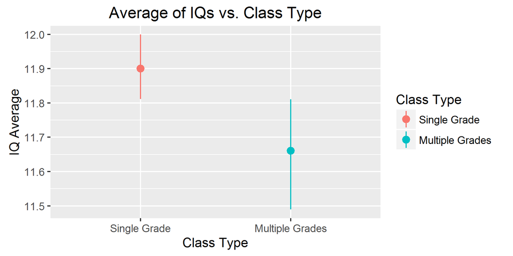

```r
##The COMB value or the multigrade or non-mutigrade class grouping may be a class-specific factor that distinguishes differences between pupils and SES or pupils and IQ
nlschools.df$COMB = mapvalues(nlschools.df$COMB,
                                from=c('1', '0'),
                                to=c('Multiple Grades', 'Single Grade'))

##Visual check IQ by COMB
ggplot(data = nlschools.df, mapping=aes(x = COMB, y = IQ, color = COMB, group = COMB)) + stat_summary(fun.data = mean_cl_boot, geom='pointrange') + labs(color = 'Class Type', x='Class Type', y='IQ Average', title = 'Average of IQs vs. Class Type')
```

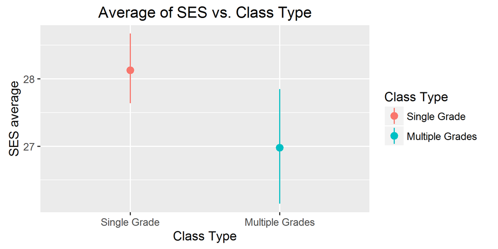

```r
#We can also check the probability that being of a certain SES is indicative of being in a Multigrade class or not through a logistic regression.

##Visual check SES  by COMB
ggplot(data = nlschools.df, mapping=aes(x = COMB, y = SES, color = COMB, group = COMB)) + stat_summary(fun.data = mean_cl_boot, geom='pointrange') + labs(color = 'Class Type', x='Class Type', y='SES average', title = 'Average of SES vs. Class Type')
```

Are the differences between class types significantly different?

```r
#Determine with T-test
#Source: http://ww2.coastal.edu/kingw/statistics/R-tutorials/independent-t.html
multigrade.IQ = subset(nlschools.df, subset = COMB=='Multiple Grades', select = IQ)
singlegrade.IQ = subset(nlschools.df, subset = COMB=='Single Grade', select = IQ)


#Default is two tailed test
t.test(multigrade.IQ, singlegrade.IQ)
```

```
##
##  Welch Two Sample t-test
##
## data:  multigrade.IQ and singlegrade.IQ
## t = -2.4427, df = 1106.2, p-value = 0.01473
## alternative hypothesis: true difference in means is not equal to 0
## 95 percent confidence interval:
##  -0.4315345 -0.0470796
## sample estimates:
## mean of x mean of y
##  11.66057  11.89988
```

According to the t-test, COMB (being in a multigrade class or not) is highly likely (p < 0.05) to indicate a student’s IQ range (or vice versa) in the Netherland pupils in this dataset.

```r
multigrade.SES = subset(nlschools.df, subset = COMB=='Multiple Grades', select = SES)
singlegrade.SES = subset(nlschools.df, subset = COMB=='Single Grade', select = SES)

#Default is two tailed test
t.test(multigrade.SES, singlegrade.SES)
```

```
##
##  Welch Two Sample t-test
##
## data:  multigrade.SES and singlegrade.SES
## t = -2.289, df = 1172.6, p-value = 0.02225
## alternative hypothesis: true difference in means is not equal to 0
## 95 percent confidence interval:
##  -2.1329714 -0.1640939
## sample estimates:
## mean of x mean of y
##  26.97933  28.12786
```

According to the t-test, COMB (being in a multigrade class or not) is highly likely (p < 0.05) to indicate a student’s SES range (or vice versa) in the Netherland pupils in this dataset.

Logistic Regressions We can also check the probability that being of a certain SES is indicative of being in a Multigrade class or not through a logistic regression. Essentially, we can perform similar checks with other categorical variables in the dataset, if more categorical variables were available.

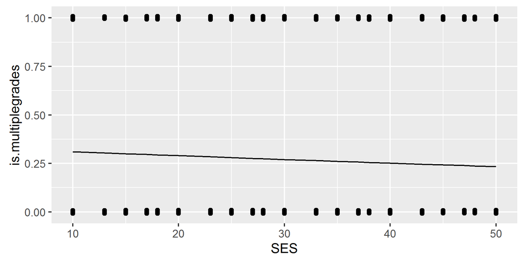

```r
#Given that COMB is a categorical variable indicating multi=grade classes or no, I considered COMB in a logistical model

# create a categorical variable is.multiplegrade to indicate multiple grade class
nlschools.df = mutate(nlschools.df, is.multiplegrades = COMB == 'Multiple Grades')

# point.jitter: saves typing later on
point.jitter = geom_point(position=position_jitter(height=0.02, width=0), size=1.5)

# convert is.multiplegrades to numeric for linear regression
nlschools.df$is.multiplegrades = mapvalues(nlschools.df$is.multiplegrades, from = c('TRUE', 'FALSE'), to = c(1,0))

# fit a logistic regression
glm.model = glm(is.multiplegrades ~ SES, data = nlschools.df, family = 'binomial')

# extract the predictions and residuals
glm.augment = augment(glm.model, data = nlschools.df, type.predict = 'response', type.residuals = 'response')

# plot the predictions
ggplot(data=glm.augment, mapping=aes(x=SES, y=is.multiplegrades)) + point.jitter + geom_line(mapping=aes(x=SES, y=.fitted))
```

The range of predictions of class type tend fall below 50%.

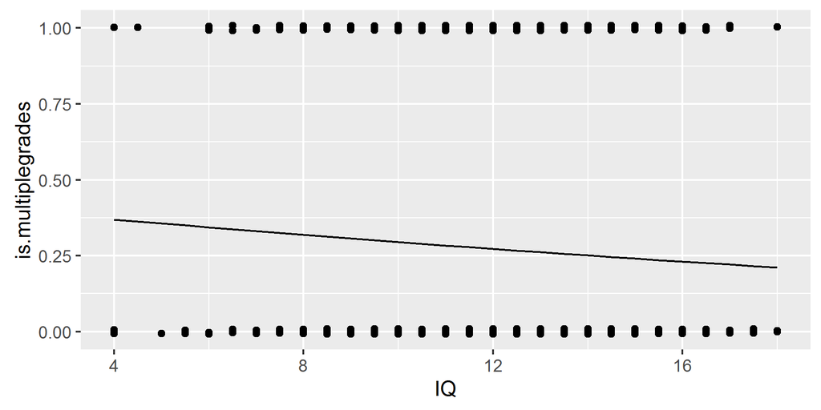

```r
#Given that COMB is a categorical variable indicating multi=grade classes or no, I considered COMB in a logistical model

# fit a logistic regression
glm.model = glm(is.multiplegrades ~ IQ, data = nlschools.df, family = 'binomial')

# extract the predictions and residuals
glm.augment = augment(glm.model, data = nlschools.df, type.predict = 'response', type.residuals = 'response')

# plot the predictions
ggplot(data=glm.augment, mapping=aes(x=IQ, y=is.multiplegrades)) + point.jitter + geom_line(mapping=aes(x=IQ, y=.fitted))
```

Again, the range of predictions of class type tend fall below 50%.

While both logistical regression model plots did not yield a model that would predict class type based on SES or IQ, it is still clear that there is a significant IQ and SES difference based on the above analyses. Nevertheless, since categorical grouping may yield more insight about students. For instance, it may be helpful to have an IQ groups variable or other characteristics of pupils available.

Question 2. When did students perform better or worse on the language exam? Describe which variables had the most important effects.

Backwards and forward variable selection

```r
#Obtain dataset again without adjustment made in previous analysis
nlschools.df = nlschools

#Excluded class because class ids do not yield meaningful information/patterns in this data
nlschools.df = subset(nlschools.df, select = c(lang, IQ, GS, SES, COMB) )

#Ascertained dataframe sctructure for analysis
nlschools.df = as.data.frame(nlschools.df)

#Changed factor into number for standardzing the data
nlschools.df$COMB = as.numeric(nlschools.df$COMB)

#To better view relationships, I normalized the data to zero mean and unit variance
#Source: http://stackoverflow.com/questions/15215457/standardize-data-columns-in-r
scaled.nlschools = scale(nlschools.df)

#Ascertained dataframe structure for analysis
scaled.nlschools = as.data.frame(scaled.nlschools)

#Obtain the full model that considers all variables
full.model = lm(lang ~ ., data = scaled.nlschools)
summary(full.model)
```

```
##
## Call:
## lm(formula = lang ~ ., data = scaled.nlschools)
##
## Residuals:
##     Min      1Q  Median      3Q     Max
## -2.9869 -0.5106  0.0502  0.5473  2.7795
##
## Coefficients:
##               Estimate Std. Error t value Pr(>|t|)
## (Intercept)  1.303e-15  1.610e-02   0.000    1.000
## IQ           5.493e-01  1.699e-02  32.333  < 2e-16 ***
## GS          -1.650e-02  1.619e-02  -1.019    0.308
## SES          1.791e-01  1.707e-02  10.493  < 2e-16 ***
## COMB        -8.356e-02  1.613e-02  -5.179 2.42e-07 ***
## ---
## Signif. codes:  0 '***' 0.001 '**' 0.01 '*' 0.05 '.' 0.1 ' ' 1
##
## Residual standard error: 0.7699 on 2282 degrees of freedom
## Multiple R-squared:  0.4083, Adjusted R-squared:  0.4073
## F-statistic: 393.7 on 4 and 2282 DF,  p-value: < 2.2e-16
```

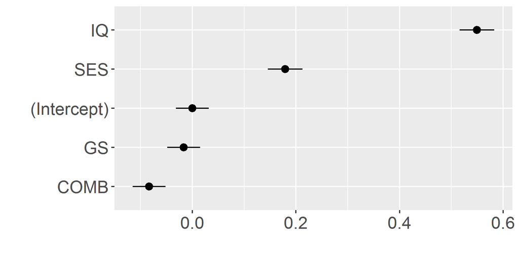

```r
#The following is the function I used for this purpose:
plot.coef = function(model) {
  plot.df = data.frame( names = names(coefficients(model)), coef = coefficients(model), lower = confint(model)[, 1], upper = confint(model)[, 2])
  plot.df$names = with(plot.df, reorder(x = names, X = coef, FUN=mean))
  plot.out = ggplot(data = plot.df, mapping = aes(x = names, y = coef, ymin = lower, ymax = upper)) + geom_pointrange() + coord_flip() + labs(x='', y= '')
  return(plot.out)
}

#Checked the coefficients for the linear model
plot.coef(full.model) + theme(text = element_text(size=18))
```

```r
# Forward variable selection:
# Initial model: use no variables
empty.model = lm(lang ~ 1, data = scaled.nlschools)

#View the output of the forward selection: lowest AIC is preferred
forward.step = step(empty.model, direction='forward', scope = formula(full.model))
```

```
## Start:  AIC=1
## lang ~ 1
##
##        Df Sum of Sq    RSS      AIC
## + IQ    1    850.12 1435.9 -1060.51
## + SES   1    288.63 1997.4  -305.68
## + COMB  1     33.03 2253.0   -30.29
## <none>              2286.0     1.00
## + GS    1      0.99 2285.0     2.01
##
## Step:  AIC=-1060.51
## lang ~ IQ
##
##        Df Sum of Sq    RSS     AIC
## + SES   1    66.808 1369.1 -1167.5
## + COMB  1    18.035 1417.8 -1087.4
## <none>              1435.9 -1060.5
## + GS    1     0.001 1435.9 -1058.5
##
## Step:  AIC=-1167.47
## lang ~ IQ + SES
##
##        Df Sum of Sq    RSS     AIC
## + COMB  1   15.8741 1353.2 -1192.1
## <none>              1369.1 -1167.5
## + GS    1    0.5896 1368.5 -1166.5
##
## Step:  AIC=-1192.14
## lang ~ IQ + SES + COMB
##
##        Df Sum of Sq    RSS     AIC
## <none>              1353.2 -1192.1
## + GS    1   0.61596 1352.6 -1191.2
```

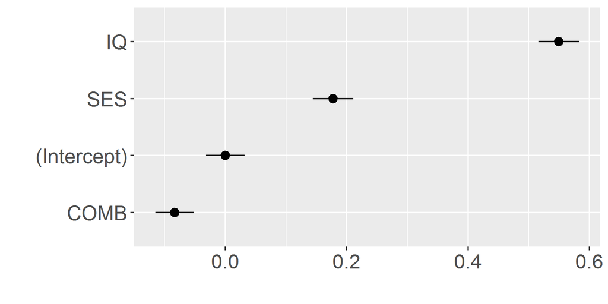

```r
#View the coefficients
plot.coef(forward.step) + theme(text = element_text(size=18))
```

Findings: * GS (class size) was removed.

```r
#Backward variable selection

#View the output: Lowest AIC is preferred
linear.back.model = step(full.model)
```

```
## Start:  AIC=-1191.19
## lang ~ IQ + GS + SES + COMB
##
##        Df Sum of Sq    RSS      AIC
## - GS    1      0.62 1353.2 -1192.14
## <none>              1352.6 -1191.19
## - COMB  1     15.90 1368.5 -1166.46
## - SES   1     65.26 1417.8 -1085.42
## - IQ    1    619.63 1972.2  -330.66
##
## Step:  AIC=-1192.14
## lang ~ IQ + SES + COMB
##
##        Df Sum of Sq    RSS      AIC
## <none>              1353.2 -1192.14
## - COMB  1     15.87 1369.1 -1167.47
## - SES   1     64.65 1417.8 -1087.42
## - IQ    1    619.63 1972.8  -331.95
```

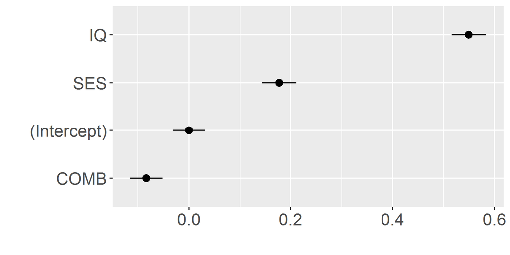

```r
#View the coeffificents
plot.coef(linear.back.model) + theme(text = element_text(size=18))
```

Findings:

- Likewise, GS (class size) was removed.

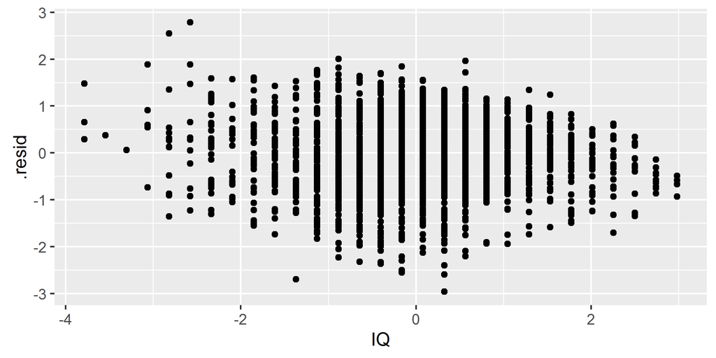

```r
#Viewing residuals according to the forward step model.
#Either forward or backward models would have been fine. The above analyses only considered a df = 1, a linear relationship between the variable and lang (language test score).

lm.augment = augment(forward.step, data= scaled.nlschools)

# pattern in IQ
ggplot(data=lm.augment, mapping=aes(x=IQ, y=.resid)) + geom_point()
```

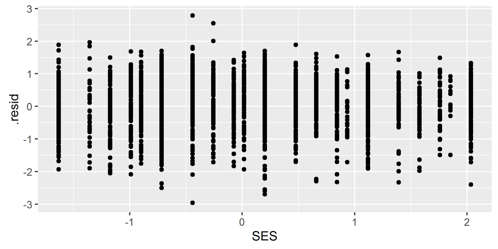

```r
#  lack of a pattern in SES
ggplot(data=lm.augment, mapping=aes(x=SES, y=.resid)) + geom_point()
```

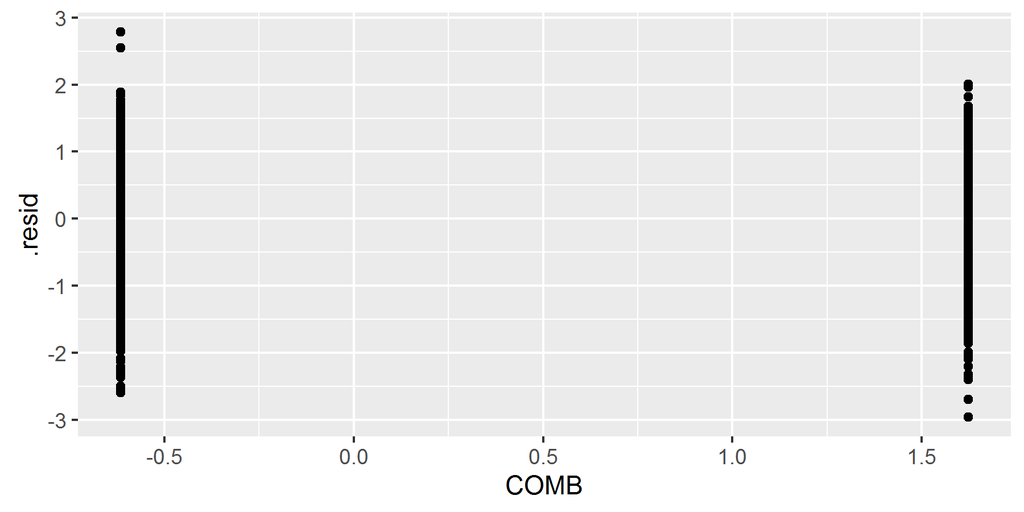

```r
# Even though, COMB (class type) is a categorical variable, it was still interesting to observe the residual differences on the two binary values (multigrade or not multigrade). There seems to be a lack of a pattern.
ggplot(data=lm.augment, mapping=aes(x=COMB, y=.resid)) + geom_point()
```

Still, the residual for IQ reveals that the current fitted model is not complex enough to fit the data and make reasonable predictions across all multiple regression variables.

Exploring non-linear fits for the multiple regression model may be more useful.

```r
# Use splines to fit a better model
library(gam)
#Considered linear and non-linear predictor fits as well.
# let R choose df for splines in each input variable
scope.list = list(
  "COMB" = ~ 1 + COMB,
  "SES" = ~ 1 + SES + ns(SES, df=2) + ns(SES, df=3) + ns(SES, df=4),
  "GS" = ~ 1 + GS + ns(GS, df=2) + ns(GS, df=3) + ns(GS, df=4),
  "IQ" = ~ 1 + IQ + ns(IQ, df=2) + ns(IQ, df=3) + ns(IQ, df=4))


#Forward selection: Used the empty model to start
start.model = gam(lang ~ 1, data = scaled.nlschools)
# variable selection. output suppressed because it's long:
spline.step = step.gam(start.model, scope = scope.list)
```

```
## Start:  lang ~ 1; AIC= 6493.225
## Step:1 lang ~ IQ ; AIC= 5431.715
## Step:2 lang ~ SES + IQ ; AIC= 5324.752
## Step:3 lang ~ COMB + SES + IQ ; AIC= 5300.08
## Step:4 lang ~ COMB + ns(SES, df = 2) + IQ ; AIC= 5294.077
```

Contrary to the previous residual observations, the spline model chose to fit a nonlinear fit to account for SES.

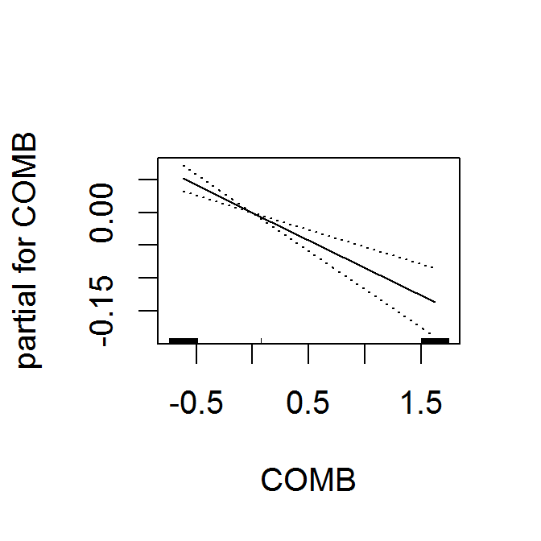

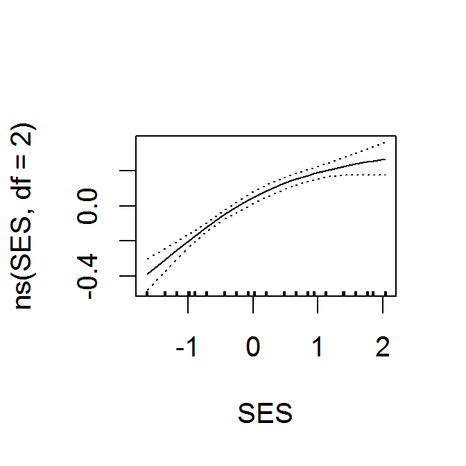

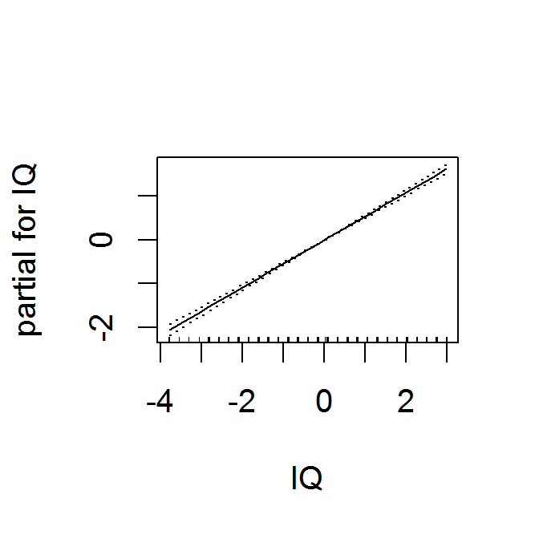

```r
# View the forward selection fitted model with nonlinear splines
plot.gam(spline.step, se=T)
```

Upon viewing the graphs indicating the error bar predictions along with the model fit, while SES seems to have a more even distribution of predictions on both sides of the predicted values, IQ still lacks evenly distributed error ranges for its predicted values. The error bar range is wider at lower IQ and higher IQ extremes.

3. Do you think there are interactions in the effects of the variables on the language exam score? Speculate as to the cause of any such effects that you think should be included.

```r
# Start with the GAM model, with splines from the previous model
start.model = lm(formula(spline.step), data = scaled.nlschools)

# the full model is the GAM plus all linear interactions found to be informative in the previous forward variable selection
# I.E., Step:4 lang ~ COMB + ns(SES, df = 2) + IQ ; AIC= 5294.077
all.interactions = lm(lang ~ .^2 + ns(SES, df = 2) + IQ + COMB, data = scaled.nlschools)

# do forward variable selection. note start is the GAM and not the empty model
# output suppressed due to length
interactions.gam.step = step(start.model, direction='forward', scope = formula(all.interactions))
```

```
## Start:  AIC=-1198.15
## lang ~ COMB + ns(SES, df = 2) + IQ
##
##           Df Sum of Sq    RSS     AIC
## + IQ:COMB  1    8.7603 1339.7 -1211.0
## <none>                 1348.5 -1198.2
## + GS       1    0.6618 1347.8 -1197.3
##
## Step:  AIC=-1211.05
## lang ~ COMB + ns(SES, df = 2) + IQ + COMB:IQ
##
##        Df Sum of Sq    RSS     AIC
## <none>              1339.7 -1211.0
## + GS    1   0.89959 1338.8 -1210.6
```

```r
formula(interactions.gam.step)
```

```
## lang ~ COMB + ns(SES, df = 2) + IQ + COMB:IQ
```

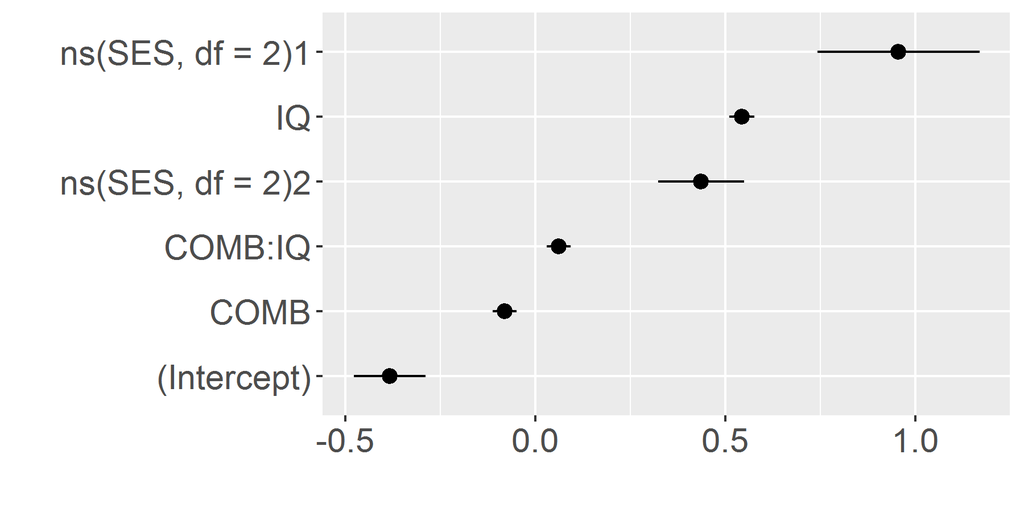

```r
# View plot
plot.coef(interactions.gam.step)+ theme(text = element_text(size=18))
```

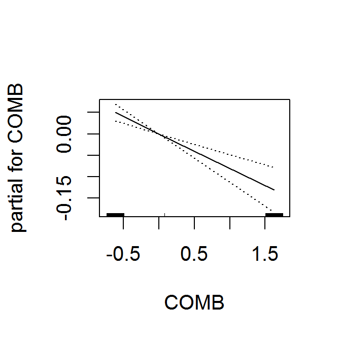

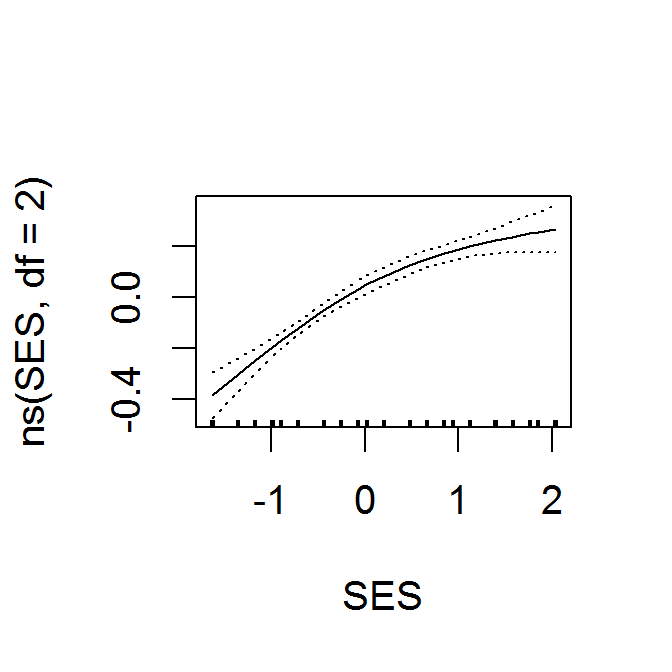

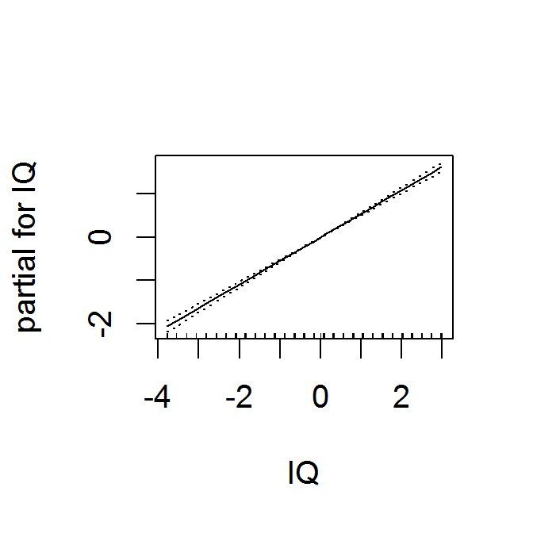

```r
# plot the splines (interactions are not shown)
plot.gam(interactions.gam.step, se=T)
```

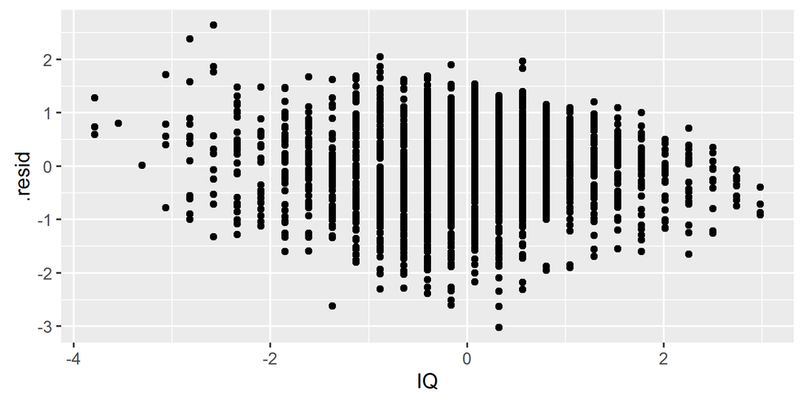

```r
#Obtain the residuals and examine all of the terms
gam.augment = mutate(scaled.nlschools, .fitted=predict(interactions.gam.step), .resid = lang - .fitted)

# pattern in IQ
ggplot(data = gam.augment, mapping=aes(x=IQ, y=.resid)) + geom_point()
```

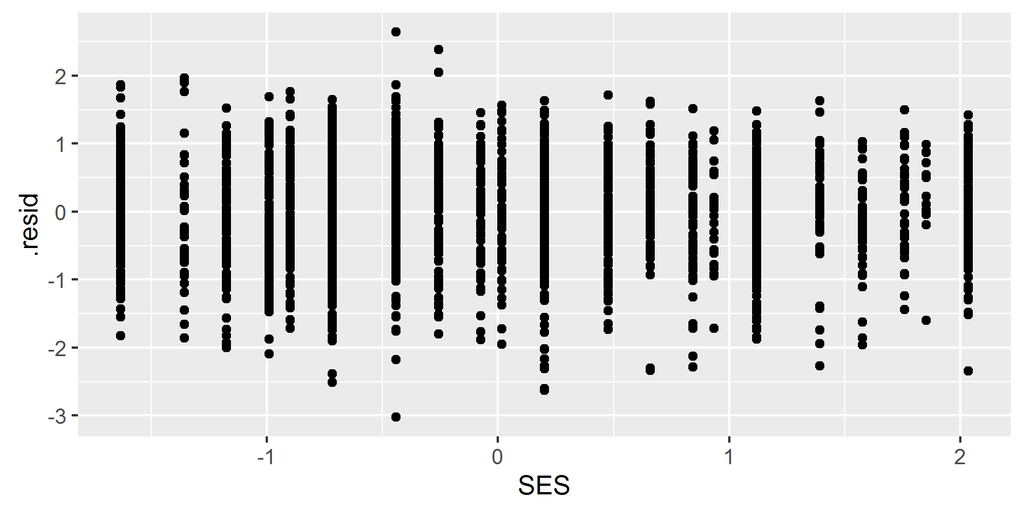

```r
# lack of a pattern in SES
ggplot(data = gam.augment, mapping=aes(x=SES, y=.resid)) + geom_point()
```

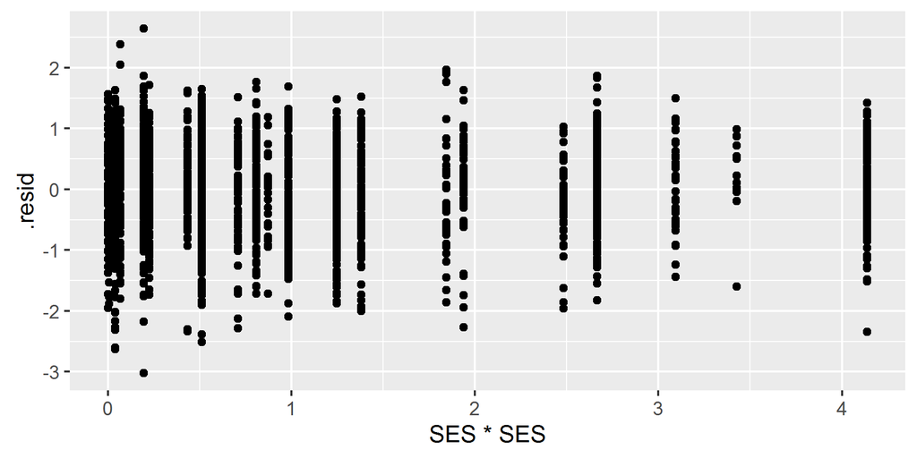

```r
# lack of a pattern in SES with df= 2
ggplot(data = gam.augment, mapping=aes(x=SES*SES, y=.resid)) + geom_point()
```

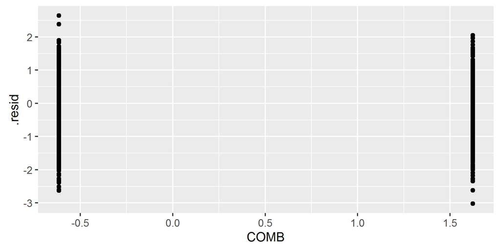

```r
# lack of a pattern in COMB
ggplot(data = gam.augment, mapping=aes(x=COMB, y=.resid)) + geom_point()
```

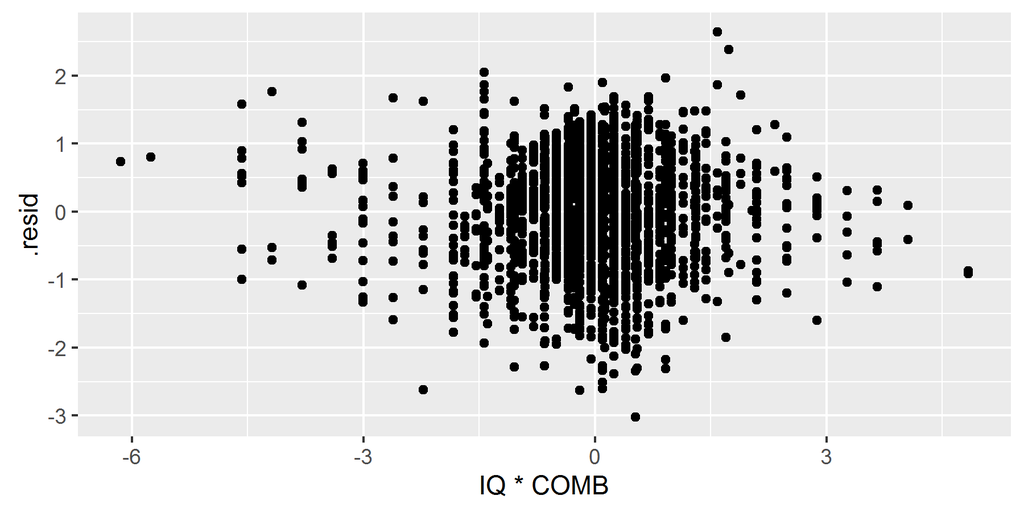

```r
# pattern in IQ score * Class type
ggplot(data = gam.augment, mapping=aes(x=IQ*COMB, y=.resid)) + geom_point()
```

Co-plots may yield better insight on the interactions:

```r
library(car)
```

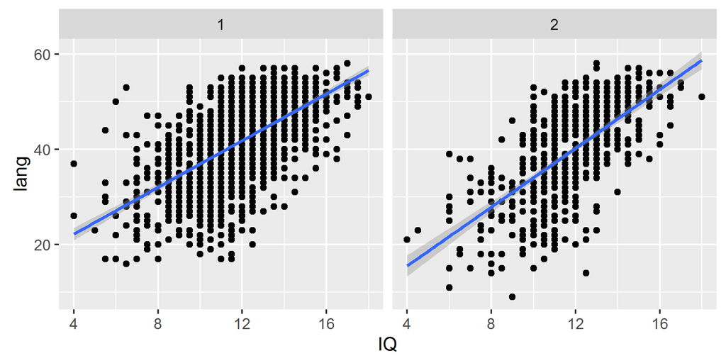

```r
#Check/Validate with co-plot esp. for nominal variables
#When the conditioning variable is categorical we can just use facet_wrap(). Here is one of the interactions that remained in the GAM model.
ggplot(data = nlschools.df, mapping = aes(y=lang, x = IQ)) + geom_point() + geom_smooth(method='lm') + facet_wrap('COMB')
```

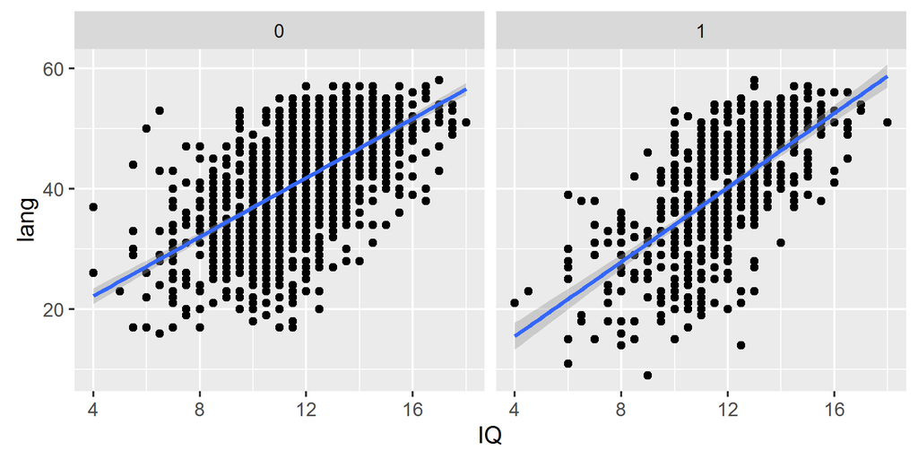

```r
#If I were to unscale the values, the trend would be the same
ggplot(data = nlschools, mapping = aes(y=lang, x = IQ)) + geom_point() + geom_smooth(method='lm') + facet_wrap('COMB')
```

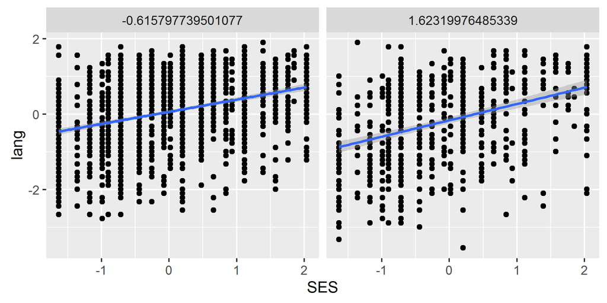

```r
#The co-plot deomonstrates how language test scores may be affected by
ggplot(data = scaled.nlschools, mapping = aes(y=lang, x = SES)) + geom_point() + geom_smooth(method='lm') + facet_wrap('COMB')
```

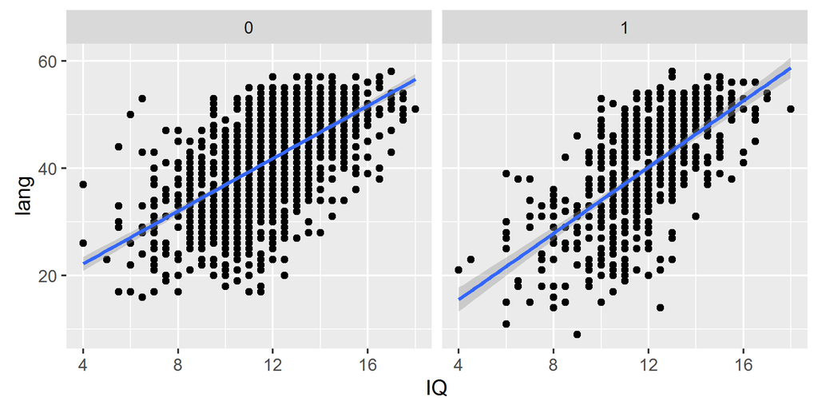

```r
#If I were to unscale the values, the trend would be the same
ggplot(data = nlschools, mapping = aes(y=lang, x = IQ)) + geom_point() + geom_smooth(method='lm') + facet_wrap('COMB')
```

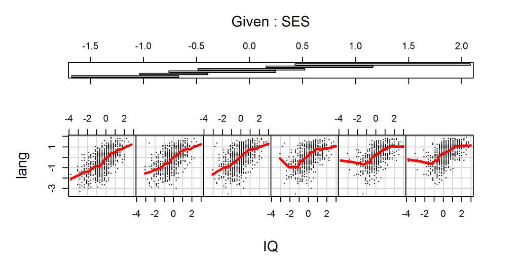

```r
coplot(data= scaled.nlschools, lang ~ IQ  | SES, panel=panel.smooth, cex=.1, span=.1, rows=1, lwd=3)
```